# MS4S09

**Task A – Text Mining**

```r
library(readr)

# Load the data set
dataset <- read_csv("MS4S09_CW_Book_Reviews.csv")
head(dataset)
```

```
## # A tibble: 6 × 11
##   Title            Book_Price Reviewer_id Rating   Time Review_title Review_text
##   <chr>                 <dbl> <chr>        <dbl>  <dbl> <chr>        <chr>
## 1 In Six Days: Wh…      10.2  APD7XINUVG…      4 9.99e8 Solid testi… "Working f…
## 2 Lord Jim              15.6  AITANZIKX8…      5 9.16e8 &quot;You d… "A terrifi…
## 3 White Socks Only       5.16 AYB19RB36G…      4 1.34e9 White Socks… "As I open…
## 4 The Secret of t…      15.0  A1BOLCK0Q5…      5 1.28e9 great!       "Excellent…
## 5 Left to Tell: D…      17.5  A3WKJ88K78…      5 1.36e9 Great Book   "This book…
## 6 Don't Make Me T…      20.9  A1E6I4IPWW…      5 1.20e9 Don't think… "Excellent…
## # ℹ 4 more variables: Found_helpful_ratio <dbl>, Publisher <chr>,
## #   First_author <chr>, Genre <chr>
```

```r
# Convert Rating to numeric
dataset$Rating <- as.numeric(dataset$Rating)

# Print the column names
colnames(dataset)
```

```
##  [1] "Title"               "Book_Price"          "Reviewer_id"
##  [4] "Rating"              "Time"                "Review_title"
##  [7] "Review_text"         "Found_helpful_ratio" "Publisher"
## [10] "First_author"        "Genre"
```

```r
# Load necessary libraries
library(tidytext)
library(dplyr)
```

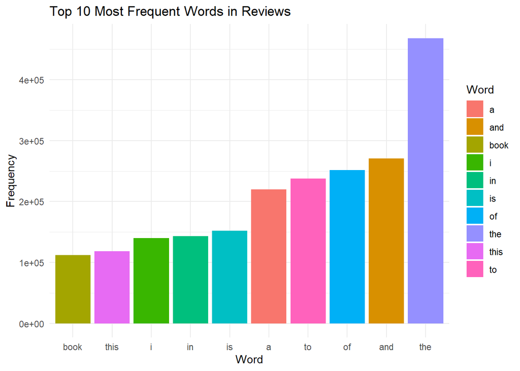

```r
library(ggplot2)
library(forcats)

# Tokenize the text
tokenized_text <- dataset %>%
  unnest_tokens(word, Review_text)

# Explore word frequency
word_freq <- tokenized_text %>%
  count(word, sort = TRUE)

# Visualize top words
top_words_plot <- word_freq %>%
  slice_max(order_by = n, n = 10) %>%
  ggplot(aes(x = fct_reorder(word, n), y = n, fill = word)) +
  geom_col() +
  labs(title = "Top 10 Most Frequent Words in Reviews",
       x = "Word",
       y = "Frequency",
       fill = "Word") +
  theme_minimal()

# Show the plot
print(top_words_plot)
```

**Task B – Sentiment Analysis**

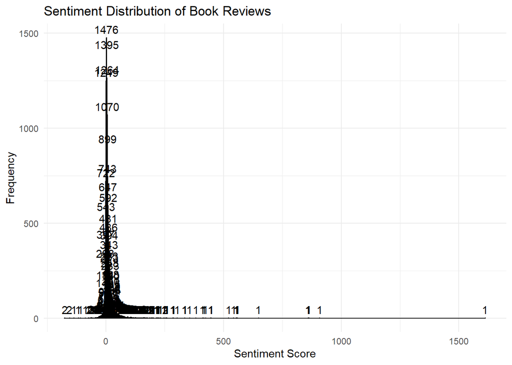

```r
# Load necessary libraries
library(tidytext)
library(dplyr)
library(ggplot2)
library(forcats)
library(wordcloud)
# Load the bing lexicon
bing_lexicon <- get_sentiments("bing")

# Perform sentiment analysis using bing lexicon
sentiment_scores <- tokenized_text %>%
  inner_join(bing_lexicon, by = "word") %>%
  group_by(Title) %>%
  summarise(sentiment_score = sum(sentiment == "positive") - sum(sentiment == "negative"))
# Visualize sentiment distribution
sentiment_distribution_plot <- ggplot(sentiment_scores, aes(x = sentiment_score)) +
  geom_histogram(binwidth = 1, fill = "skyblue", color = "black") +
  labs(title = "Sentiment Distribution of Book Reviews",
       x = "Sentiment Score",
       y = "Frequency") +
  theme_minimal() +
  geom_text(aes(label = ..count..), stat = "count", vjust = -0.5)

# Identify overall sentiment (positive/negative/neutral)
sentiment_scores <- sentiment_scores %>%
  mutate(sentiment = case_when(
    sentiment_score > 0 ~ "Positive",
    sentiment_score < 0 ~ "Negative",
    TRUE ~ "Neutral"
  ))

# Visualize overall sentiment distribution
overall_sentiment_distribution_plot <- sentiment_scores %>%
  ggplot(aes(x = sentiment, fill = sentiment)) +
  geom_bar() +
  labs(title = "Overall Sentiment Distribution of Book Reviews",
       x = "Sentiment",
       y = "Frequency",
       fill = "Sentiment") +
  theme_minimal() +
  geom_text(aes(label = ..count..), stat = "count", position = position_stack(vjust = 0.5))

# Show the plots
print(sentiment_distribution_plot)
```

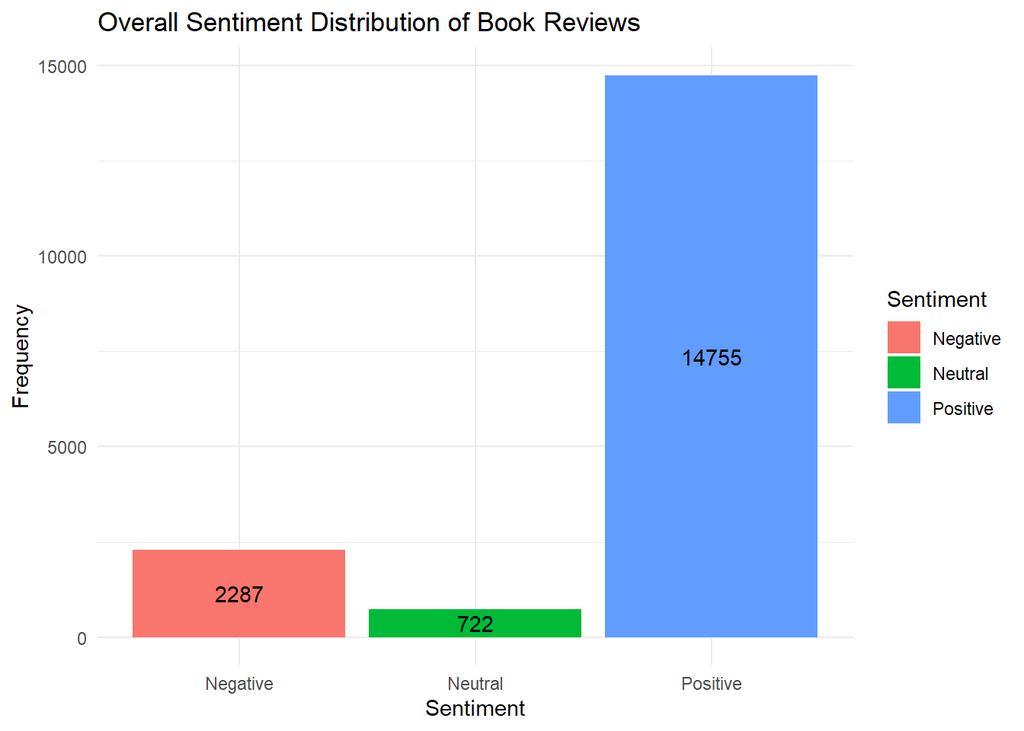

```r
print(overall_sentiment_distribution_plot)
```

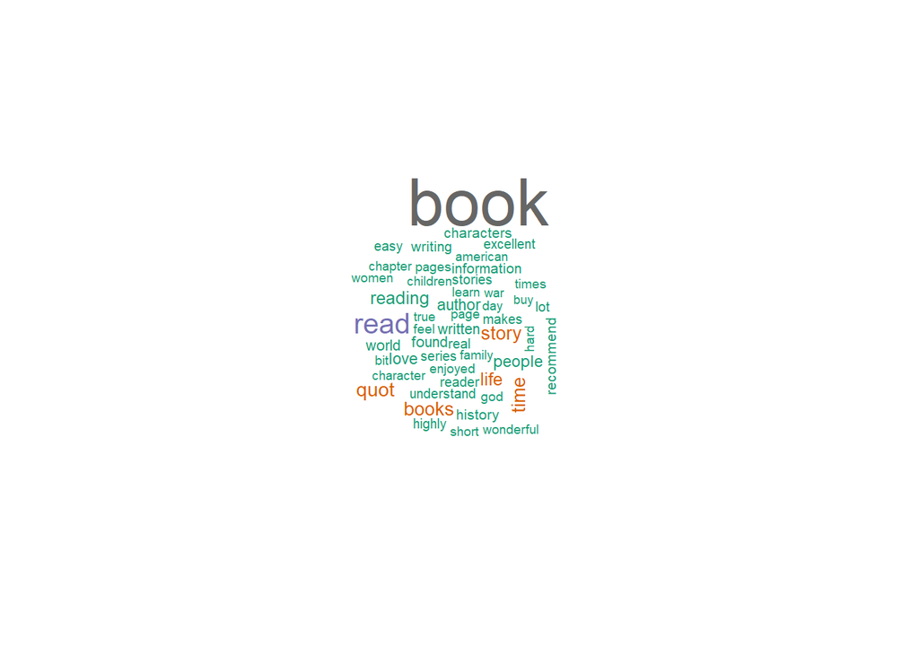

```r
# Create a word cloud for positive sentiment
positive_words <- sentiment_scores %>%
  filter(sentiment == "Positive") %>%
  pull(Title)

positive_wordcloud <- tokenized_text %>%
  filter(Title %in% positive_words) %>%
  anti_join(stop_words) %>%
  count(word) %>%
  with(wordcloud(word, n, max.words = 50, scale = c(3, 0.5), colors = brewer.pal(8, "Dark2")))
```

```r
print(positive_wordcloud)
```

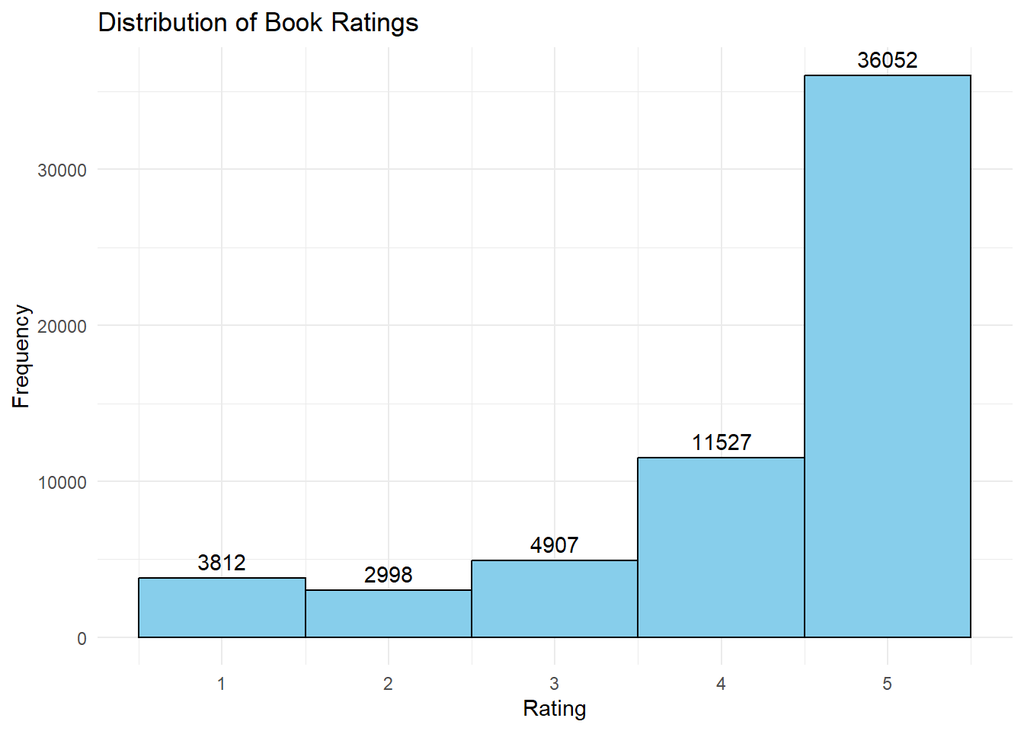

```r
# Visualize distribution of book ratings
rating_distribution_plot <- dataset %>%
  ggplot(aes(x = Rating)) +
  geom_histogram(binwidth = 1, fill = "skyblue", color = "black") +
  labs(title = "Distribution of Book Ratings",
       x = "Rating",
       y = "Frequency") +
  theme_minimal() +
  geom_text(aes(label = ..count..), stat = "count", vjust = -0.5)

# Show the plot
print(rating_distribution_plot)
```

**• Informative conclusions:**

The collective analysis of sentiment distribution, overall sentiment categories, positive sentiment word cloud, and book rating distribution provides a comprehensive understanding of the sentiment landscape within the book reviews dataset. Readers express predominantly positive sentiments, aligning with the higher distribution of positive ratings. The insights gained from these analyses can inform authors, publishers, and readers about the prevailing sentiments and rating trends, aiding in better understanding and decision-making in the literary domain.

**Task C – Topic Modelling**

```r
# Load necessary libraries
library(tidytext)
library(dplyr)
library(tidyr)
library(tm)
library(topicmodels)

# Load the dataset
dataset <- read_csv("MS4S09_CW_Book_Reviews.csv")
```

[figure not shown]

```r
# Reduce the dataset (adjust 'sample_size' as needed)
set.seed(123)
sample_size <- 500
reduced_dataset <- dataset %>% sample_n(sample_size)

# Combine review title and text into a single text column
reduced_dataset <- reduced_dataset %>%
  mutate(Review_combined = paste(Review_title, Review_text, sep = " "))

# Create a document-term matrix
corpus <- Corpus(VectorSource(reduced_dataset$Review_combined))
dtm <- DocumentTermMatrix(corpus)

# Convert the document-term matrix to a matrix
dtm_matrix <- as.matrix(dtm)

# Fit an LDA model
lda_model <- LDA(dtm_matrix, k = 5)

# Get the most probable terms for each topic
topic_terms <- terms(lda_model, 10)

# Assign topics to reviews
topic_assignments <- tidy(lda_model, matrix = "beta") %>%
  gather(key = "topic", value = "beta", -term) %>%
  arrange(desc(beta)) %>%
  group_by(term) %>%
  slice_head(n = 1) %>%
  ungroup()

# Merge topics back to the original dataset
dataset_with_topics <- reduced_dataset %>%
  left_join(topic_assignments, by = c("Review_combined" = "term"))

# Visualize topic distribution
topic_distribution_plot <- topic_assignments %>%
  ggplot(aes(x = reorder(term, -beta), y = beta, fill = factor(topic))) +
  geom_col(show.legend = FALSE) +
  labs(title = "Topic Distribution of Reviews",
       x = "Term",
       y = "Beta (Weight in Topic)",
       fill = "Topic") +
  theme_minimal() +
  theme(axis.text.x = element_text(angle = 45, hjust = 1))

# Show the plot
print(topic_distribution_plot)
```

```r
# Print top terms for each topic
print(topic_terms)
```

```
##       Topic 1 Topic 2 Topic 3 Topic 4 Topic 5
##  [1,] "the"   "the"   "the"   "the"   "the"
##  [2,] "and"   "and"   "and"   "and"   "and"
##  [3,] "that"  "this"  "for"   "this"  "this"
##  [4,] "book"  "for"   "that"  "that"  "book"
##  [5,] "this"  "that"  "his"   "for"   "that"
##  [6,] "for"   "book"  "this"  "book"  "was"
##  [7,] "with"  "are"   "with"  "was"   "for"
##  [8,] "you"   "with"  "was"   "with"  "you"
##  [9,] "have"  "but"   "her"   "his"   "but"
## [10,] "are"   "not"   "book"  "not"   "with"
```

**Limitation:**

The analysis was performed on a reduced dataset due to computational constraints. The original dataset, being large, presented challenges in processing efficiency. While the reduced dataset facilitated the analysis, it may not fully capture the diversity and nuances present in the complete set of book reviews.

```r
# Load necessary libraries
library(tidytext)
library(dplyr)
library(ggplot2)
library(forcats)
library(randomForest)
# Train a Random Forest classifier for sentiment prediction
# Convert Rating to numeric if needed
dataset$Rating <- as.numeric(dataset$Rating)

# Check for missing values in Rating
if (any(is.na(dataset$Rating))) {
  stop("There are missing values in the Rating column. Handle them before proceeding.")
}

# Ensure sentiment_label is a factor
dataset <- dataset %>%
  mutate(sentiment_label = ifelse(Rating >= 4, "Positive", "Negative")) %>%
  mutate(sentiment_label = as.factor(sentiment_label))

# Select relevant columns for the model
model_data <- dataset %>%
  select(Review_text, sentiment_label)

# Ensure Review_text is character
model_data$Review_text <- as.character(model_data$Review_text)

# Train Random Forest model
random_forest_model <- randomForest(sentiment_label ~ Review_text, data = model_data, ntree = 100)

# Print the model summary
print(random_forest_model)
```

```
##
## Call:
##  randomForest(formula = sentiment_label ~ Review_text, data = model_data,      ntree = 100)
##                Type of random forest: classification
##                      Number of trees: 100
## No. of variables tried at each split: 1
##
##         OOB estimate of  error rate: 27.02%
## Confusion matrix:
##          Negative Positive class.error
## Negative     3603     8114   0.6924981
## Positive     7907    39672   0.1661868
```

```r
# Make predictions on the training data
predictions <- predict(random_forest_model, newdata = model_data)

# Evaluate model accuracy
confusion_matrix <- table(predictions, model_data$sentiment_label)
print(confusion_matrix)
```

```
##
## predictions Negative Positive
##    Negative    11708        2
##    Positive        9    47577
```

**Task D – Further exploration**

**Conclusion:**

The Random Forest classifier was employed for sentiment prediction based on book reviews. Here are the key findings:

Model Summary:

**Future Work:** Class Imbalance Mitigation:

Address the significant class imbalance in sentiment classes. Explore oversampling, undersampling, or alternative sampling strategies. Feature Engineering Exploration:

Experiment with diverse text representations (e.g., TF-IDF, word embeddings). Enhance the model’s ability to capture sentiment nuances through feature engineering. Hyperparameter Tuning:

Conduct systematic hyperparameter search for the Random Forest model. Utilize grid search or randomized search to optimize model performance. Ensemble Method Investigation:

Explore ensemble methods (stacking, boosting) for combining model predictions. Evaluate potential improvements in generalization and model robustness. Temporal Analysis and User-specific Sentiment:

Investigate sentiment trends over time in book reviews. Explore personalized sentiment analysis based on individual reviewer behavior.